# Apuntes FP2

## Álgebra (ecuaciones)

#### Regla de 3

Esta regla se usa para casos de proporcionalidad directa, donde cuando dos magnitudes están relacionadas y un crecimiento en una de ellas provoca un crecimiento en la otra. El uso típico es en porcentajes. En general, **multiplicamos en diagonal y dividimos por el número que falta**.

- **Ejemplo 1 (pincha para expandir)**

  Si un pantalón cuesta 24€ y lo rebajan un 20%, ¿cuánto cuesta ahora?
  $$\begin{cases}
  100\% \longrightarrow 24€ \\
  \quad \quad \quad \quad \quad \quad \quad \Rightarrow x = \frac{80 \times 24}{100} = 19.2€ \\
  80\% \longrightarrow x\\
  \end{cases}$$
- **Ejemplo 2 (pincha para expandir)**

  Si una colonia cuesta 12€ sin IVA y el IVA es del 14%, ¿cuál es el precio final de la colonia?
  $$\begin{cases}
  100\% \longrightarrow 12€ \\
  \quad \quad \quad \quad \quad \quad \quad \Rightarrow x = \frac{114 \times 12}{100} = 13.68€ \\
  114\% \longrightarrow x\\
  \end{cases}$$

## Análisis (funciones)

### Dominio y recorrido

Para estudiar el dominio y el recorrido de una función a partir de una gráfica, lo que haremos será:

- Dominio: nos fijamos en el eje de abajo, y miramos la “sombra” de la gráfica.
- Recorrido: nos fijamos en el eje vertical, y miramos la “sombra” horizontal de la gráfica.

### Crecimiento y decrecimiento

Para estudiar el crecimiento y el decrecimiento de una función, miraremos la gráfica siempre de izquierda a derecha, y la función crecerá en los **intervalos** donde “suba” o vaya “cuesta arriba”, y decrece allí donde la función “baje”.

### Máximos y mínimos

Una función tiene un máximo cuando pasa de creciente a decreciente (es decir, cuando tiene una montañita). Al mismo tiempo, tendrá un mínimo cuando pase de decreciente a creciente (es decir, cuando tenga un valle).

## Probabilidad y estadística

### Probabilidad

#### Regla de Laplace

La regla de Laplace es aquella que usamos para calcular la probabilidad de que un suceso ocurra. En general, es el cociente entre los casos favorables y los casos posibles. Es importante tener en cuenta que **la probabilidad de un suceso siempre es un número que está entre 0 y 1**.

$$\begin{gather*}
P(X) = \frac{\text{Casos favorables}}{\text{Casos posibles}}
\end{gather*}$$

Para calcular probabilidades, es necesario modelar el problema previamente. Esto es, establecer una estructura que nos permita enfocar el problema y poder entenderlo apropiadamente. En general, los modelos que emplearemos serán:

1. Modelos aplicando diagramas de Venn.
2. Modelos de diagramas de árbol.
3. Modelos de urnas.

  **Ejemplo 1: urnas (pincha para expandir)**

  Si en una caja tenemos 8 bolas, de las cuales 2 son amarillas, 2 son rojas, 2 son verdes y 2 son de los tres colores anteriores, calcula:
  1. La probabilidad de sacar una bola solamente amarilla.
  2. La probabilidad de sacar una bola que tenga el color verde.
  3. La probabilidad de sacar una bola que no tenga rojo.

  Resolución: Es recomendable dibujar la urna para ver los casos más fácilmente.
  1. $$\begin{gather*}
     P(\text{Sacar una bola solo amarilla}) = \frac{\text{Casos favorables}}{\text{Casos posibles}} = \frac{2}{8} = \frac{1}{4} = 0.25
     \end{gather*}$$
  2. $$\begin{gather*}
     P(\text{Sacar una bola que tenga verde}) = \frac{\text{Casos favorables}}{\text{Casos posibles}} = \frac{4}{8} = \frac{1}{2} = 0.5
     \end{gather*}$$
  3. $$\begin{gather*}
     P(\text{Sacar una bola que no tenga rojo}) = \frac{\text{Casos favorables}}{\text{Casos posibles}} = \frac{4}{8} = \frac{1}{2} = 0.5
     \end{gather*}$$

### Estadística

Para el bloque de estadística, nos bastará con saber calcular los estadísticos más importantes, aplicando las siguientes fórmulas:

| Nombre | Símbolo/s | Fórmula | Uso |
| --- | --- | --- | --- |
| Media | $$\overline{X}, \mu$$ | $$\frac{1}{n} \sum x_i$$ | Una sola variable |
| Varianza | $$Var(X), \sigma_X^2$$ | $$\frac{1}{n} \sum (x_i-\overline{X})^2$$ | Una sola variable |
| Desviación estándar | $$\sigma_X$$ | $$\sqrt{\frac{1}{n} \sum (x_i-\overline{X})^2}$$ | Una sola variable |
| Covarianza | $$Cov(X,Y), \sigma_{XY}$$ | $$\frac{1}{n} \sum (x_i-\overline{X})(y_i-\overline{Y})$$ | Dos variables |
| Coeficiente de correlación | $$\rho_{XY}$$ | $$\frac{\sigma_{XY}}{\sigma_{Y}\sigma_{Y}}$$ | Dos variables |

  **Ejemplo 1 (pincha para expandir)**

  Supongamos que tenemos las siguientes variables:

  $$\begin{cases}
  X \text{ que toma los valores } 7,6,3,4,5\\
  Y \text{ que toma los valores } 5,4,1,3,5\\
  \end{cases}$$

  Entonces tenemos que:

  $$\begin{gather*}
  \overline{X} = \frac{7+6+3+4+5}{5} = \frac{25}{5} = 5\\
  \overline{Y} = \frac{5+4+1+3+5}{5} = \frac{18}{5} = 3.6\\ \\
  \hline\\
  Var(X) = \frac{1}{5}\left[ (7-5)^2+(6-5)^2+(3-5)^2+(4-5)^2+(5-5)^2 \right] = \frac{10}{5} = 2\\
  Var(Y) = \frac{1}{5}\left[ (5-3.6)^2+(4-3.6)^2+(1-3.6)^2+(3-3.6)^2+(5-3.6)^2 \right] = \frac{11.2}{5} = 2.24\\ \\
  \hline\\
  \sigma_X = \sqrt{Var(X)} = 1.4142\\
  \sigma_Y = \sqrt{Var(Y)} = 1.4966\\ \\
  \hline\\
  Cov(X,Y) = \frac{1}{5}\left[ (7-5)(5-3.6)+(6-5)(4-3.6)+(3-5)(1-3.6)+(4-5)(3-3.6)+(5-5)(5-3.6) \right] = \frac{9}{5} = 1.8 \\ \\
  \hline\\
  \rho_{XY} = \frac{\sigma_{XY}}{\sigma_{Y}\sigma_{Y}} = \frac{1.8}{1.4142 \times 1.4966} = 0.85042
  \end{gather*}$$

#### Moda y mediana

Otros valores estadísticos que ocasionalmente deberemos calcular son la moda y la mediana.

- La moda es aquél valor que más se repite en una variable. Si por ejemplo $X$ toma los valores $1,2,3,3,3,4,5$, la moda será $3$ por ser este el valor que más veces se repite.
- La mediana es aquél valor que divide el muestreo de una variable en dos conjuntos del mismo tamaño.

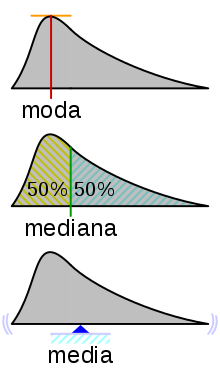

*Moda, mediana y media*

## Geometría

### Tipos de triángulos

Todos los triángulos tienen vértices, lados y ángulos. Las dos clasificaciones principales de triángulos que podemos hacer son según sus lados, o según sus ángulos. Es importante tener en cuenta que **en todos los triángulos la suma de sus ángulos siempre es 180º**.

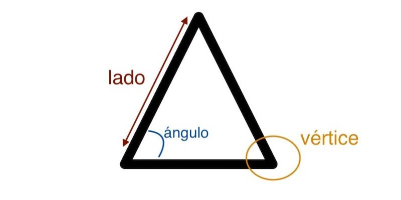

*Partes de un triángulo*

#### Según sus lados

Encontramos tres tipos principales de triángulos:

- Equilátero: Es cuando todos sus lados son iguales.
- Isósceles: Es cuando tiene dos lados iguales y uno distinto a los otros dos.
- Escaleno: Es cuando todos sus lados son diferentes.

#### Según sus ángulos

- Rectángulo: Cuando el triángulo tiene un ángulo recto (90º).
- Acutángulo: Cuando todos sus ángulos son menores que 90º.
- Obtusángulo: Cuando tiene un ángulo obtuso, es decir, mayor de 90º.

### Teorema de Pitágoras

El teorema de Pitágoras nos dice que, para un **triángulo rectángulo**, la hipotenusa al cuadrado es igual que la suma de los cuadrados de los catetos. Llamamos hipotenusa al lado mayor del triángulo, que es aquél opuesto al ángulo recto, y catetos a los otros dos lados.

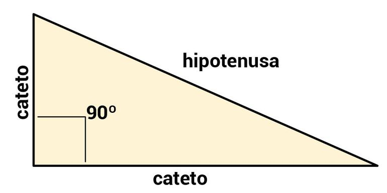

*Nombre de los lados de un triángulo rectángulo*

Así, el teorema de Pitágoras se puede enunciar como:

$$\begin{gather*}
\boxed{
h^2 = c_1^2 + c_2^2
}
\end{gather*}$$

### Áreas y perímetros

A continuación se presentan las fórmulas para realizar estos cálculos sobre figuras planas.

[output not shown]

### Volúmenes y superficies

[output not shown]

## Anexo I: Exámenes trabajados.

- 2021/06/01: Prueba ordinaria 2020 (ejercicios 1-4). El 4to ejercicio era de maximizar parábolas, comprobar en un futuro si hay que derivar o aplicar fórmula de extremos.
- 2021/06/02: Hemos finalizado la prueba de 2020, y comenzado la de Junio 2012. Procurar trabajar más las ecuaciones con ejercicios.
- 2021/06/03: Hemos llegado hasta el ejercicio 3 del examen de Junio de 2012 (incluido).